Skip to main content

# QA Gold Standard Report — GA1

Jev stage 1, Phase 2 and the pipeline against two human reviewers

Published

November 20, 2026

# Conclusions

**ImportantIn short**

**Jev stage 1 agrees with the human reviewers about as well as they agree with each other — but the two humans agree only weakly, and the main reason is a contradiction in the reviewer guide, not the difficulty of the task.** Until the guide is fixed and the SUPPORTS rows re-checked, this round cannot tell a better model from a worse one.

1. **Jev sits inside the human spread.** On set A, human–human κ is 0.33 [0.24–0.41]. Jev agrees with R1 at 0.48 [0.38–0.57] and with R2 at 0.25 [0.16–0.33] — one above the human ceiling, one below it. A third reviewer whose verdicts were Jev’s would not stand out.
2. **The human ceiling is low — κ around 0.3 is only “fair” agreement.** Almost every disagreement is SUPPORTS or REFUTES against NOT_ENOUGH_INFO; the reviewers practically never disagree on *direction*, and neither does Jev when it is certain (no gold REFUTES in its certain-SUPPORTS cell, 2 gold SUPPORTS in its certain-REFUTES cell).
3. **The low ceiling is mostly the guide** (see below). It says both that SUPPORTS need not “cover all” of a claim and that it must “reach all of it”. R1 gave SUPPORTS 102 times in set A and R2 35 times. Of the 62 rows where R1 said SUPPORTS and R2 NOT_ENOUGH_INFO, 34 carry an R1 note saying the support was partial or limited in scope (“only in Africa”, “supports part of the claim”).
4. **Phase 2 makes the call stricter; it does not make it more accurate.** On the routed rows it moves agreement away from R1 (0.45 [0.30–0.60] → 0.29 [0.15–0.44]) and towards R2 (0.25 [0.16–0.35] → 0.41 [0.24–0.56]). Which reading is “right” is the same open question as the guide’s — what counts as support.
5. **Routing drops real findings.** The uncertain cells, which Phase 2 never sees, hold 6 gold REFUTES (REFUTES/uncertain) and 6 gold SUPPORTS (NEI/uncertain). If recall matters, routing the uncertain SUPPORTS/REFUTES cells is the lever.
6. **Corpus-level recall is not measurable with this sample.** The NEI/certain cell is ~99% of the corpus and has 40 rows; see the warning under Precision and recall.
7. **Set B (key papers) supports no conclusion about the models** — every interval is wide and human κ is 0.23 [0.03–0.41]. One finding stands: most agreed key papers are NOT_ENOUGH_INFO (55 of 74), i.e. the papers IPBES itself cites mostly do not show the claim from their abstract. That bounds any abstract-only fact checker, human or model.

**Is it good enough?** As a stage-1 screen, yes: it behaves like a human reviewer and does not confuse the direction of evidence when certain. As a final verdict, not yet validated. **Next:** fix the guide, have *both* reviewers re-check their own SUPPORTS rows under the fixed rule, re-run this report, and only then judge model or routing changes.

# What this measures

Two reviewers (R1, R2) independently judged sampled (claim, paper) pairs from claim + title + abstract alone, blind to every model output. The sample was drawn from **Jev stage 1** (`scorer_config = jev_atomic_bm`) only; every “stage 1” label below, `NOT_ENOUGH_INFO` included, is Jev’s.

- **Set A** — citing works, balanced: 40 pairs per Jev cell (3 labels × certain/uncertain). The two *certain* SUPPORTS/REFUTES cells are exactly the pairs Phase 2 reviews, so 80 rows carry an LLM verdict.
- **Set B** — key papers, drawn proportional to Jev’s own label ratio. Phase 2 reviews every key paper, so all rows carry an LLM verdict.

**Gold** = rows where both reviewers agree (rule fixed before reviewing). Disagreements are the human ceiling and are excluded from gold. `CANNOT_JUDGE` is a property of the instrument and is never scored.

# Humans against humans, models against humans

Each point is Cohen’s κ between a rater and one reviewer, on the same rows, with a 95% bootstrap interval. The grey band is the human–human κ and its interval: a rater inside the band agrees with a reviewer about as well as the other reviewer does. Unweighted — a like-for-like comparison on the sample, not a corpus estimate.

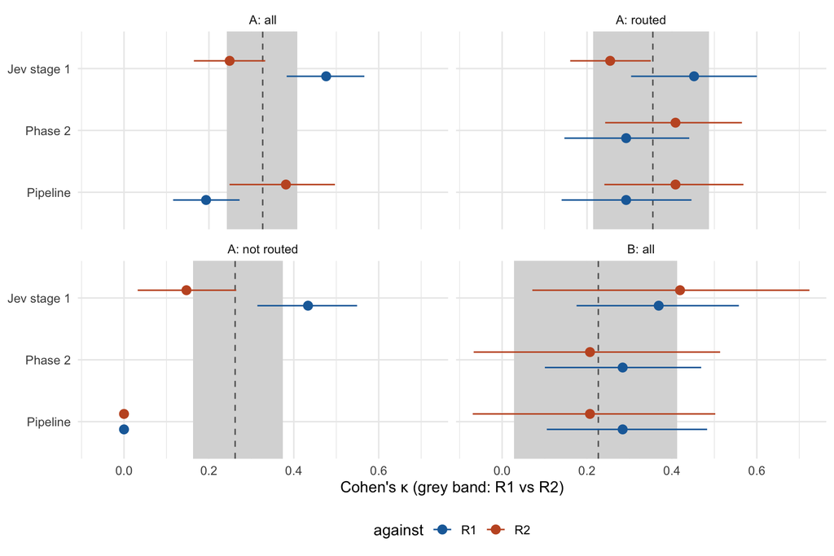

```r
kp <- e$kappas |>
  mutate(subset = factor(subset, c("A: all", "A: routed", "A: not routed", "B: all")))
hum <- kp |> filter(rater == "R1 (human)")
mod <- kp |> filter(rater != "R1 (human)") |>
  mutate(rater = factor(rater, c("Pipeline", "Phase 2", "Jev stage 1")))
ggplot(mod, aes(kappa, rater, colour = reviewer)) +
  geom_rect(data = hum, aes(xmin = lo, xmax = hi, ymin = -Inf, ymax = Inf),
            inherit.aes = FALSE, fill = "grey85") +
  geom_vline(data = hum, aes(xintercept = kappa), colour = "grey40", linetype = "dashed") +
  geom_pointrange(aes(xmin = lo, xmax = hi), position = position_dodge(width = 0.5)) +
  facet_wrap(~subset, ncol = 2) +
  scale_colour_manual(values = c(R1 = "#1b6ca8", R2 = "#c4572a"), name = "against") +
  labs(x = "Cohen's κ (grey band: R1 vs R2)", y = NULL) +
  theme_minimal(base_size = 12) + theme(legend.position = "bottom")
```

```r
e$kappas |>
  transmute(Subset = subset, Rater = rater, `vs` = reviewer, n,
            Agreement = sprintf("%.0f%%", 100 * agreement),
            `κ [95% CI]` = sprintf("%.2f [%.2f–%.2f]", kappa, lo, hi)) |>
  tbl(caption = "Pipeline κ on 'A: not routed' is 0 by construction: it calls every unrouted row NOT_ENOUGH_INFO.")
```

Pipeline κ on ‘A: not routed’ is 0 by construction: it calls every unrouted row NOT_ENOUGH_INFO.

| Subset | Rater | vs | n | Agreement | κ [95% CI] |
| --- | --- | --- | --- | --- | --- |
| A: all | R1 (human) | R2 | 222 | 56% | 0.33 [0.24–0.41] |
| A: all | Jev stage 1 | R1 | 222 | 65% | 0.48 [0.38–0.57] |
| A: all | Jev stage 1 | R2 | 222 | 49% | 0.25 [0.16–0.33] |
| A: all | Pipeline | R1 | 222 | 47% | 0.19 [0.12–0.27] |
| A: all | Pipeline | R2 | 222 | 75% | 0.38 [0.25–0.50] |
| A: routed | R1 (human) | R2 | 77 | 55% | 0.36 [0.22–0.49] |
| A: routed | Jev stage 1 | R1 | 77 | 68% | 0.45 [0.30–0.60] |
| A: routed | Jev stage 1 | R2 | 77 | 43% | 0.25 [0.16–0.35] |
| A: routed | Phase 2 | R1 | 77 | 52% | 0.29 [0.15–0.44] |
| A: routed | Phase 2 | R2 | 77 | 61% | 0.41 [0.24–0.56] |
| A: routed | Pipeline | R1 | 77 | 52% | 0.29 [0.14–0.45] |
| A: routed | Pipeline | R2 | 77 | 61% | 0.41 [0.24–0.57] |
| A: not routed | R1 (human) | R2 | 145 | 57% | 0.26 [0.16–0.37] |
| A: not routed | Jev stage 1 | R1 | 145 | 63% | 0.43 [0.31–0.55] |
| A: not routed | Jev stage 1 | R2 | 145 | 52% | 0.15 [0.03–0.26] |
| A: not routed | Pipeline | R1 | 145 | 45% | 0.00 [0.00–0.00] |
| A: not routed | Pipeline | R2 | 145 | 82% | 0.00 [0.00–0.00] |
| B: all | R1 (human) | R2 | 85 | 72% | 0.23 [0.03–0.41] |
| B: all | Jev stage 1 | R1 | 85 | 78% | 0.37 [0.18–0.56] |
| B: all | Jev stage 1 | R2 | 85 | 89% | 0.42 [0.07–0.72] |
| B: all | Phase 2 | R1 | 85 | 75% | 0.28 [0.10–0.47] |
| B: all | Phase 2 | R2 | 85 | 87% | 0.21 [-0.07–0.51] |
| B: all | Pipeline | R1 | 85 | 75% | 0.28 [0.11–0.48] |
| B: all | Pipeline | R2 | 85 | 87% | 0.21 [-0.07–0.50] |

# The reviewer guide contradicts itself

Reviewer 2 pointed this out after finishing set A. `REVIEWER_GUIDE.md` defines `SUPPORTS` as:

> The paper does not have to prove the claim, **cover all of it**, or use the same words.

and rule 3 says:

> To support a compound claim the paper has to **reach all of it**.

R2 reports applying the first (lenient) reading throughout, without checking whether a finding covered a whole compound claim. Yet R2 is the *stricter* of the two by a wide margin, so a re-check of R2’s SUPPORTS under rule 3 can only make R2 stricter still and *widen* the gap. The notes show the gap comes from the other side: R1 gave SUPPORTS to partial and scope-limited findings.

The guide also has a second, quieter gap: it says a contrary finding **for one region, taxon or period** is `REFUTES`, but is silent on whether a *confirming* finding for one region supports a general claim. Many of R1’s notes are exactly that case.

**NoteFixed after round 1 (2026-11-20)**

The guide now (a) drops “cover all of it” from the `SUPPORTS` definition, so a compound claim must be reached in **every assertion**; and (b) adds rule 5 on **scope**: a confirming finding for one region, taxon, period or scale is `SUPPORTS`, a contrary one is `REFUTES`, and a paper reporting both is `REFUTES`. Everything in this report is round 1, judged under the old guide.

Jev’s prompt matches (b) only partly: regional support reads as `SUPPORTS`, but it has no whole-claim rule for compound claims and no REFUTES-wins precedence for mixed papers. Neither does the Phase 2 prompt. Changing either prompt means a full rescore, so it waits until round 2 shows whether the disagreements concentrate there.

```r
nA |>
  filter(verdict == "SUPPORTS") |>
  group_by(Reviewer = reviewer) |>
  summarise(SUPPORTS = n(), `with a note` = sum(!is.na(note)),
            `note says partial / limited scope` = sum(partial)) |>
  tbl(caption = "Set A SUPPORTS verdicts and their notes. 'Partial' is a keyword match (part, only, though, but, not) — indicative, not exact.")
```

Set A SUPPORTS verdicts and their notes. ‘Partial’ is a keyword match (part, only, though, but, not) — indicative, not exact.

| Reviewer | SUPPORTS | with a note | note says partial / limited scope |
| --- | --- | --- | --- |
| R1 | 102 | 81 | 64 |
| R2 | 35 | 25 | 3 |

```r
split_r1 |>
  filter(partial) |>
  select(id, `R1 note` = note) |>
  head(15) |>
  tbl(caption = "R1 notes on rows where R1 said SUPPORTS and R2 NOT_ENOUGH_INFO (first 15).")
```

R1 notes on rows where R1 said SUPPORTS and R2 NOT_ENOUGH_INFO (first 15).

| id | R1 note |
| --- | --- |
| GA1-A-0160 | Only about snakes in Alaska |
| GA1-A-0136 | Only about bottled water in Netherlands |
| GA1-A-0125 | Only in India |
| GA1-A-0115 | This could be labelled as NOT_ENOUGH_INFO since the abstract doesn’t acknowledge that changes in communities are caused by human driven changes but the abstract still discusses the complexities behind… |
| GA1-A-0055 | Only about fish resources for food |
| GA1-A-0054 | Only about freshwater |
| GA1-A-0171 | Abstract supports part of claim around “consequences of changes often depend on details of the ecosystem” |
| GA1-A-0134 | Only about energy consumption |
| GA1-A-0037 | Only in diabetic mice |
| GA1-A-0071 | Only in north eastern Mediterranean |
| GA1-A-0020 | Only concerncing gut microbiaota |
| GA1-A-0156 | Only declines in freshwater and marine species |
| GA1-A-0143 | Only in Shanghai, China |
| GA1-A-0211 | Though on hedgerows and not forests, underlines the pollination and waterflow regulation aspects in the claim |
| GA1-A-0145 | I would say the abstract supports the “including public access and participation” part of the claim |

# Reviewer agreement

```r
e$agreement |>
  transmute(Set = set, `Double-reviewed` = n, Agreement = sprintf("%.1f%%", 100 * agreement),
            `Cohen's κ` = sprintf("%.3f", kappa), Gold = n_gold, `Gold, scorable` = n_scorable) |>
  tbl()
```

|  | Set | Double-reviewed | Agreement | Cohen’s κ | Gold | Gold, scorable |
| --- | --- | --- | --- | --- | --- | --- |
| A | A | 240 | 58.3% | 0.397 | 140 | 125 |
| B | B | 99 | 74.7% | 0.507 | 74 | 61 |

```r
d |>
  tidyr::pivot_longer(c(R1, R2), names_to = "Reviewer", values_to = "verdict") |>
  count(set, Reviewer, verdict) |>
  tidyr::pivot_wider(names_from = verdict, values_from = n, values_fill = 0) |>
  rename(Set = set) |>
  tbl(caption = "Verdicts per reviewer.")
```

Verdicts per reviewer.

| Set | Reviewer | CANNOT_JUDGE | NOT_ENOUGH_INFO | REFUTES | SUPPORTS |
| --- | --- | --- | --- | --- | --- |
| A | R1 | 15 | 80 | 43 | 102 |
| A | R2 | 18 | 160 | 27 | 35 |
| B | R1 | 13 | 58 | 2 | 26 |
| B | R2 | 14 | 76 | 2 | 7 |

```r
d |>
  filter(!is.na(R1), !is.na(R2), R1 != R2) |>
  count(set, `R1 → R2` = paste(R1, "→", R2), sort = TRUE) |>
  rename(Set = set) |>
  tbl(caption = "Disagreements by direction.")
```

Disagreements by direction.

| Set | R1 → R2 | n |
| --- | --- | --- |
| A | SUPPORTS → NOT_ENOUGH_INFO | 62 |
| A | REFUTES → NOT_ENOUGH_INFO | 24 |
| B | SUPPORTS → NOT_ENOUGH_INFO | 20 |
| A | SUPPORTS → REFUTES | 5 |
| A | NOT_ENOUGH_INFO → REFUTES | 4 |
| A | SUPPORTS → CANNOT_JUDGE | 2 |
| B | NOT_ENOUGH_INFO → SUPPORTS | 2 |
| A | NOT_ENOUGH_INFO → CANNOT_JUDGE | 1 |
| A | NOT_ENOUGH_INFO → SUPPORTS | 1 |
| A | REFUTES → SUPPORTS | 1 |
| B | NOT_ENOUGH_INFO → REFUTES | 1 |
| B | REFUTES → NOT_ENOUGH_INFO | 1 |
| B | SUPPORTS → CANNOT_JUDGE | 1 |

# Set A: gold per Jev cell

Unweighted counts, so every cell reads at its own 40 rows.

```r
d |>
  filter(set == "A") |>
  mutate(gold = coalesce(gold, "(disagree)")) |>
  count(`Jev stage 1` = stratum, gold) |>
  tidyr::pivot_wider(names_from = gold, values_from = n, values_fill = 0) |>
  mutate(`Routed to Phase 2` = grepl("^(SUPPORTS|REFUTES)/certain$", `Jev stage 1`)) |>
  tbl()
```

| Jev stage 1 | (disagree) | CANNOT_JUDGE | NOT_ENOUGH_INFO | SUPPORTS | REFUTES | Routed to Phase 2 |
| --- | --- | --- | --- | --- | --- | --- |
| NOT_ENOUGH_INFO/certain | 5 | 5 | 29 | 1 | 0 | FALSE |
| NOT_ENOUGH_INFO/uncertain | 15 | 2 | 17 | 6 | 0 | FALSE |
| REFUTES/certain | 20 | 1 | 5 | 2 | 12 | TRUE |
| REFUTES/uncertain | 21 | 0 | 11 | 2 | 6 | FALSE |
| SUPPORTS/certain | 15 | 2 | 6 | 17 | 0 | TRUE |
| SUPPORTS/uncertain | 24 | 5 | 6 | 5 | 0 | FALSE |

```r
d |>
  filter(set == "A", routed) |>
  mutate(gold = coalesce(gold, "(disagree)")) |>
  count(`Jev stage 1` = stratum, `Phase 2` = llm_label, gold) |>
  tidyr::pivot_wider(names_from = gold, values_from = n, values_fill = 0) |>
  tbl(caption = "Phase 2 verdict against gold, on the 80 routed rows.")
```

Phase 2 verdict against gold, on the 80 routed rows.

| Jev stage 1 | Phase 2 | (disagree) | CANNOT_JUDGE | NOT_ENOUGH_INFO | REFUTES | SUPPORTS |
| --- | --- | --- | --- | --- | --- | --- |
| REFUTES/certain | NOT_ENOUGH_INFO | 10 | 1 | 2 | 1 | 0 |
| REFUTES/certain | REFUTES | 10 | 0 | 3 | 11 | 2 |
| SUPPORTS/certain | NOT_ENOUGH_INFO | 8 | 1 | 2 | 0 | 5 |
| SUPPORTS/certain | SUPPORTS | 7 | 1 | 4 | 0 | 12 |

# Precision and recall

Weighted by `1/p_include`, so these are **corpus-level** estimates, not sample-level ones. Three predictors: Jev stage 1 alone; Phase 2 on the rows it reviews; and the pipeline’s final call (stage 1 routed **and** Phase 2 agreed, otherwise NOT_ENOUGH_INFO; for key papers Phase 2’s verdict is final).

**Warning**

**Read `hits` next to every rate.** The Jev NOT_ENOUGH_INFO/certain cell stands for ~99% of the corpus, so each of its 40 rows carries a weight in the hundreds of thousands. A single human REFUTES there outweighs every REFUTES stage 1 caught, which is why recall swings between ~1.00 and ~0 depending on the reference. Precision is far more stable than recall. Figures against gold are also optimistic: the excluded disagreements cluster in the uncertain cells, which are the hard cases.

```r
m <- e$metrics |>
  mutate(cell = sprintf("%s / %s (%d/%d hits)", pct(precision), pct(recall), n_hit, n_pred))
for (s in unique(m$set)) {
  cat(sprintf("\n## Set %s\n\n", s))
  m |>
    filter(set == s) |>
    select(Predictor = predictor, Label = label, reference, cell) |>
    tidyr::pivot_wider(names_from = reference, values_from = cell) |>
    rename(`vs gold` = gold, `vs R1` = R1, `vs R2` = R2) |>
    tbl(caption = "precision / recall (hits / predicted)") |>
    print()
}
```

## Set A

precision / recall (hits / predicted)

| Predictor | Label | vs gold | vs R1 | vs R2 |
| --- | --- | --- | --- | --- |
| jev_stage1 | SUPPORTS | 0.63 / 0.29 (22/34 hits) | 0.79 / 0.27 (58/73 hits) | 0.31 / 0.31 (24/73 hits) |
| jev_stage1 | REFUTES | 0.40 / 1.00 (18/38 hits) | 0.47 / 0.01 (39/79 hits) | 0.27 / 0.11 (24/79 hits) |
| jev_stage1 | NOT_ENOUGH_INFO | 0.96 / 0.99 (46/53 hits) | 0.84 / 0.99 (48/73 hits) | 0.96 / 0.96 (61/70 hits) |
| phase2_routed | SUPPORTS | 0.75 / 0.70 (12/16 hits) | 0.83 / 0.61 (19/23 hits) | 0.52 / 0.67 (12/23 hits) |
| phase2_routed | REFUTES | 0.69 / 0.92 (11/16 hits) | 0.62 / 0.76 (16/26 hits) | 0.54 / 0.18 (14/26 hits) |
| phase2_routed | NOT_ENOUGH_INFO | 0.29 / 0.33 (4/10 hits) | 0.20 / 0.43 (5/28 hits) | 0.60 / 0.48 (21/28 hits) |
| pipeline | SUPPORTS | 0.75 / 0.15 (12/16 hits) | 0.83 / 0.08 (19/23 hits) | 0.52 / 0.15 (12/23 hits) |
| pipeline | REFUTES | 0.69 / 0.39 (11/16 hits) | 0.62 / 0.00 (16/26 hits) | 0.54 / 0.04 (14/26 hits) |
| pipeline | NOT_ENOUGH_INFO | 0.95 / 1.00 (67/93 hits) | 0.82 / 1.00 (71/176 hits) | 0.95 / 0.99 (140/173 hits) |

## Set B

precision / recall (hits / predicted)

| Predictor | Label | vs gold | vs R1 | vs R2 |
| --- | --- | --- | --- | --- |
| jev_stage1 | SUPPORTS | 1.00 / 0.81 (4/4 hits) | 1.00 / 0.31 (8/8 hits) | 0.50 / 0.58 (4/8 hits) |
| jev_stage1 | REFUTES | – / 0.00 (0/0 hits) | – / 0.00 (0/0 hits) | – / 0.00 (0/0 hits) |
| jev_stage1 | NOT_ENOUGH_INFO | 0.96 / 1.00 (55/57 hits) | 0.74 / 1.00 (58/78 hits) | 0.94 / 0.95 (72/77 hits) |
| phase2_routed | SUPPORTS | 1.00 / 0.40 (2/2 hits) | 1.00 / 0.23 (6/6 hits) | 0.34 / 0.29 (2/6 hits) |
| phase2_routed | REFUTES | – / 0.00 (0/0 hits) | – / 0.00 (0/0 hits) | – / 0.00 (0/0 hits) |
| phase2_routed | NOT_ENOUGH_INFO | 0.93 / 1.00 (55/59 hits) | 0.72 / 1.00 (58/80 hits) | 0.91 / 0.95 (72/79 hits) |
| pipeline | SUPPORTS | 1.00 / 0.40 (2/2 hits) | 1.00 / 0.23 (6/6 hits) | 0.34 / 0.29 (2/6 hits) |
| pipeline | REFUTES | – / 0.00 (0/0 hits) | – / 0.00 (0/0 hits) | – / 0.00 (0/0 hits) |
| pipeline | NOT_ENOUGH_INFO | 0.93 / 1.00 (55/59 hits) | 0.72 / 1.00 (58/80 hits) | 0.91 / 0.95 (72/79 hits) |

# Rows

```r
d |>
  select(id, set, stratum, jev_label, jev_confidence, llm_label, pipeline, R1, R2, gold, w) |>
  DT::datatable(filter = "top", rownames = FALSE, options = list(pageLength = 25))
```

| id | set | stratum | jev_label | jev_confidence | llm_label | pipeline | R1 | R2 | gold | w |
| --- | --- | --- | --- | --- | --- | --- | --- | --- | --- | --- |
| GA1-A-0001 | A | SUPPORTS/certain | SUPPORTS | 0.97 | SUPPORTS | SUPPORTS | NOT_ENOUGH_INFO | NOT_ENOUGH_INFO | NOT_ENOUGH_INFO | 6468.574999999989 |
| GA1-A-0002 | A | SUPPORTS/certain | SUPPORTS | 0.86 | SUPPORTS | SUPPORTS | SUPPORTS | SUPPORTS | SUPPORTS | 6468.574999999989 |
| GA1-A-0003 | A | SUPPORTS/certain | SUPPORTS | 0.66 | NOT_ENOUGH_INFO | NOT_ENOUGH_INFO | SUPPORTS | NOT_ENOUGH_INFO |  | 6468.574999999989 |
| GA1-A-0004 | A | SUPPORTS/certain | SUPPORTS | 0.64 | NOT_ENOUGH_INFO | NOT_ENOUGH_INFO | NOT_ENOUGH_INFO | SUPPORTS |  | 6468.574999999989 |
| GA1-A-0005 | A | SUPPORTS/certain | SUPPORTS | 0.88 | SUPPORTS | SUPPORTS | NOT_ENOUGH_INFO | NOT_ENOUGH_INFO | NOT_ENOUGH_INFO | 6468.574999999989 |
| GA1-A-0006 | A | SUPPORTS/certain | SUPPORTS | 0.82 | SUPPORTS | SUPPORTS | SUPPORTS | REFUTES |  | 6468.574999999989 |
| GA1-A-0007 | A | SUPPORTS/certain | SUPPORTS | 0.79 | NOT_ENOUGH_INFO | NOT_ENOUGH_INFO | NOT_ENOUGH_INFO | NOT_ENOUGH_INFO | NOT_ENOUGH_INFO | 6468.574999999989 |
| GA1-A-0008 | A | SUPPORTS/certain | SUPPORTS | 0.66 | SUPPORTS | SUPPORTS | SUPPORTS | NOT_ENOUGH_INFO |  | 6468.574999999989 |
| GA1-A-0009 | A | SUPPORTS/certain | SUPPORTS | 0.97 | SUPPORTS | SUPPORTS | SUPPORTS | SUPPORTS | SUPPORTS | 6468.574999999989 |
| GA1-A-0010 | A | SUPPORTS/certain | SUPPORTS | 0.91 | NOT_ENOUGH_INFO | NOT_ENOUGH_INFO | SUPPORTS | SUPPORTS | SUPPORTS | 6468.574999999989 |

[output cut: 329 more lines]